# HW_SDS2

Francesco Pezone

01/07/2020

# Exercise 1)

## Point a)

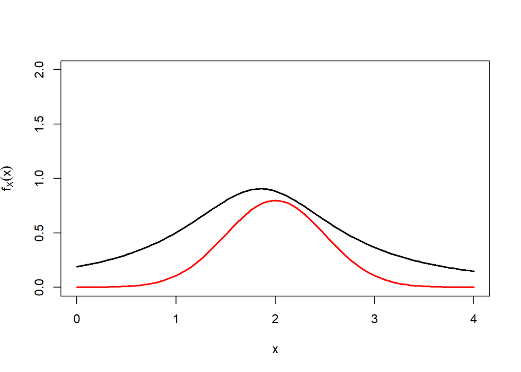

```r
# target distribution
pi <- function(x){
  dnorm(x,2,0.5)
}

# sampling distribution
q <- function(x){
  dcauchy(x,location = 1.85, scale = 0.95)
}

q_sampling <- function(x){
  rcauchy(x,location = 1.85, scale = 0.95)
}

k=2.7

curve(q(x)*k,0,4,xlab="x",ylab=expression(f[X](x)),ylim=c(0,2),lwd=2)
curve(pi(x),add=TRUE,col="red",lwd=2)
```

The foundamental part is that $q(x) \geq \pi(x)$ $\forall x \in \mathbb{R}$, for this reason even if the two distribution are shifted a little bit I don’t care about it, but I have to consider $k*q(x)$ instead of $q(x)$.

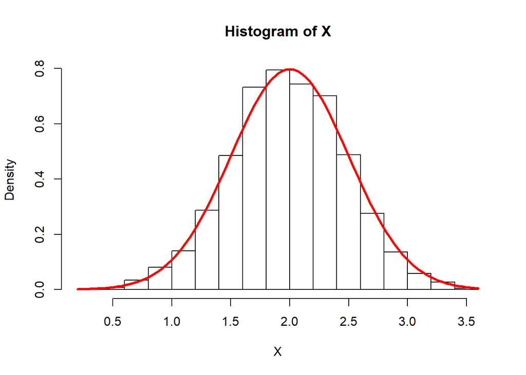

```r
# Algorithm

#
n_sim_aux=10000

# inizializing
Y=rep(NA,n_sim_aux)
E=rep(NA,n_sim_aux)
set.seed(1234)
# loop
for(i in 1:n_sim_aux){
  # sampling from cauchy
  Y[i]=q_sampling(1)

  # acceptance rejection condition
  E[i]=rbinom(1,size=1,prob=pi(Y[i])/(k*q(Y[i])))
}

# head(cbind(Y,E))

# pick only the accepted values
X <- Y[E==1]

# plotting the result
hist(X,prob=TRUE)
curve(pi(x),add=TRUE,col="red",lwd=3)
```

## Point b)

Numerically speaking the efficency is the ratio of accepted points over the total number of points:

```r
efficiency <- length(X)/n_sim_aux
round(efficiency,3)
```

```
## [1] 0.361
```

In theory since the algorithm use a Bernoulli distribution with probability $p(x) = \frac{\pi(x)}{k*q(x)}$ in order to choose if accept the point, the efficiency is given by:

$E[p(x)|q(x)] = \int_{-\infty}^{\infty} p(x)q(x) dx = \int_{-\infty}^{\infty} \frac{\pi(x)}{k*q(x)}q(x) dx = \frac{1}{k}$

```r
efficiency_th <- 1/k
round(efficiency_th,3)
```

```
## [1] 0.37
```

# Exercise 2)

## Point a)

Formally, an infinite exchangeable sequence of random variables is sequence $X_1, X_2, X_3, ...$ of random variables such that for any finite permutation σ of the indices 1, 2, 3, …, (the permutation acts on only finitely many indices, with the rest fixed), the joint probability distribution of the permuted sequence

$X_{\sigma(1)},X_{\sigma(2)},X_{\sigma(3)},...$ is the same as the joint probability distribution of the original sequence.

### 1)

From De Finetti I have

$E[X_i] = E[X_j] = \int_0^1 \theta \pi(\theta)d\theta = E_\pi[\theta]$

### 2)

$E[X_iX_j] = \int_0^1 \theta^2 \pi(\theta)d\theta = E_\pi[\theta^2]$

### 3)

I can write:

$Cov(X_i,X_j) = E[X_iX_j] - E[X_i]E[X_j] = E_\pi[\theta^2] - E_\pi[\theta]^2 = Var_\theta(\theta)$

## Point b)

This is true since a.3 is true and for the formula of the correlation, since everything is positive.

$Cor(X_i,X_j) = \frac{Var_\theta(\theta)}{\sqrt{Var(X_i)Var(X_j)}}$

## Point c)

From a.3 and the definition of correlatrion I have

$Cor(X_i,X_j) = \frac{Var_\theta(\theta)}{\sqrt{Var(X_i)Var(X_j)}} = 1$

So at the end I must have

$Var_\theta(\theta) = Var(X_i) = Var(X_j)$

## Point d)

This simply mean that $X$ and $\theta$ must have the same mean and variance so $\pi$ should be a uniform distribution or another distribution that sutisfy the condition.

# Exercise 3)

## Point a) Considerations

Considering that a dugong can grow for the first 10 years and after the size is more or less constant, if I choose $\gamma_{my} = 0.80$ I have the following curve.

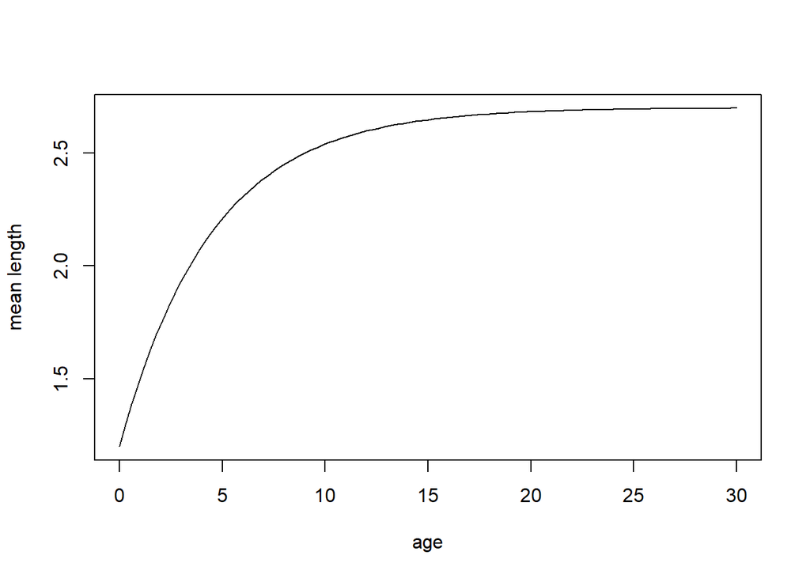

```r
mu_i <- function(x, alpha, beta, gamma){
  - beta*gamma^x + alpha
}
curve(mu_i(x, 2.7, 1.5, 0.80 ), from = 0, to = 30, xlab = 'age', ylab = 'mean length',)
```

So the code for this part is:

```r
df <- read.table("C:/Users/franc/Desktop/Data_science/SDS_2/SDS_2_Homeworks/hw/hw_1/dati_dugonghi.txt",
                 header = TRUE)
N_df <- length(df$I)

mu_i <- function(x, alpha, beta, gamma){
  - beta*gamma^x + alpha
}
Y_i <- function(y, x, alpha, beta, gamma, tau_2){
  dnorm(y, mu_i(x,alpha, beta, gamma), 1/sqrt(tau_2))
}


alpha_d <- function(alpha, prior_alpha_mean, prior_alpha_std){
  dnorm(alpha, prior_alpha_mean, prior_alpha_std)
}

beta_d <- function(beta, prior_beta_mean, prior_beta_std){
  dnorm(beta, prior_beta_mean, prior_beta_std)
}

gamma_d <- function(gamma){
  dunif(gamma)
}

tau_2_d <- function(tau, prior_tau_shape, prior_tau_rate){
  dinvgamma(tau, shape = prior_tau_shape, rate = prior_tau_rate)
}
```

## Point b)

$L(\alpha,\beta,\gamma,\tau^2) = \prod_{i = 1}^{n} Y_i = \frac{\tau^n}{(2\pi)^\frac{n}{2}}\exp \left( -\frac{\tau^2}{2} \sum_{i=1}^{n}(y_i - \alpha + \beta \gamma^{x_i})^2 \right)$

```r
lik <- function(alpha, beta, gamma, tau_2){
  prod(Y_i(df$Length, df$Age,
              alpha_d(alpha, prior_alpha_mean, prior_alpha_std),
              beta_d(beta, prior_beta_mean, prior_beta_std),
              gamma_d(gamma),
              tau_2_d(tau_2, prior_tau_shape, prior_tau_rate)))
}
```

## Point c)

Let’s write the -loglik in order simplify the computation

$l(\alpha,\beta,\gamma,\tau^2) \propto nln(\tau) -\frac{\tau^2}{2} \sum_{i=1}^{n}(y_i - \alpha + \beta \gamma^{x_i})^2$

```r
require(invgamma)
Y_log_lik <- function(alpha, beta, gamma, tau_2){
  -sum(log(Y_i(df$Length, df$Age,
              alpha_d(alpha, prior_alpha_mean, prior_alpha_std),
              beta_d(beta, prior_beta_mean, prior_beta_std),
              gamma_d(gamma),
              tau_2_d(tau_2, prior_tau_shape, prior_tau_rate))))
}


Y_log_lik_optim <- function(x){
  Y_log_lik(x[1],x[2],x[3],x[4])
}

# parameters from point d)
prior_alpha_mean <- 2.7
prior_alpha_std <- 0.5
prior_beta_mean <- 1.5
prior_beta_std <- 0.5
prior_tau_shape <- 0.1
prior_tau_rate <- 0.1
set.seed(11223344)

# those values as different each time, and not only a little bit.....
# I' not able to use method = "BFGS", since this error appear
# Error in optim(par = c(2.7, 1.1, 0.8, 0.04), Y_log_lik_optim, control = list(fnscale = -1),  :   non-finite finite-difference value [4]

optim(par = c(2.7,1.0,0.8,0.04),
      Y_log_lik_optim,control=list(fnscale=-1))$par
```

```
## [1] 3.3435447785 1.7506796953 0.5232234654 0.0001330531
```

## Point d)

Since the parameters are all indipendent the join is:

$\pi(\alpha,\beta,\gamma,\tau^2) = \pi(\alpha)\pi(\beta)\pi(\gamma)\pi(\tau^2) \propto exp(-\frac{(\alpha-2.7)^2}{2\sigma_{\alpha}^2})exp(-\frac{(\beta-1.5)^2}{2\sigma_{\beta}^2})\tau^{2(-a-1)}exp(-\frac{b}{\tau^2})$

As I wrote at the beginning, $\mu_\alpha = 2.7$ and $\mu_\beta = 1.5$, since I’m quite sure of my choices for the parameters I choose:

$\sigma_{\alpha} = 0.5 \\ \sigma_{\beta} = 0.5$

For what concern $\tau^2$ let’s pick some non informative prior:

$a = 0.1 \\b = 0.1$

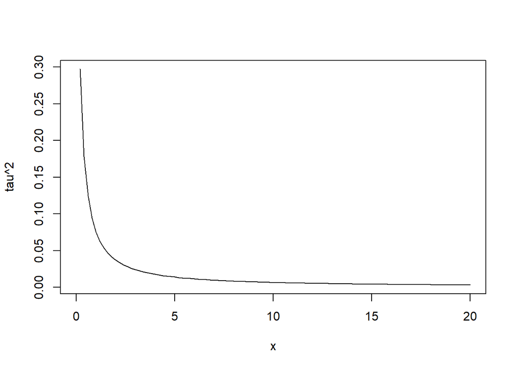

```r
require(invgamma)
curve(dinvgamma(x, 0.1,0.1), from = 0, to = 20, ylab = 'tau^2')
```

So the parameters are:

```r
prior_alpha_mean <- 2.7
prior_alpha_std <- 0.5
prior_beta_mean <- 1.5
prior_beta_std <- 0.5
prior_tau_shape <- 0.1
prior_tau_rate <- 0.1
```

## Point e)

Posterior:

$\pi(\alpha,\beta,\gamma,\tau^2|Y) \propto L(\alpha,\beta,\gamma,\tau^2) \pi(\alpha,\beta,\gamma,\tau^2) \propto \frac{\tau^n}{(2\pi)^\frac{n}{2}}\exp \left( -\frac{\tau^2}{2} \sum_{i=1}^{n}(y_i - \alpha + \beta \gamma^{x_i})^2 \right) exp(-\frac{(\alpha-2.7)^2}{2\sigma_{\alpha}^2})exp(-\frac{(\beta-1.5)^2}{2\sigma_{\beta}^2})\tau^{2(-a-1)}exp(-\frac{b}{\tau^2})$

Now let’s see the full conditional distributions.

### full conditional of $\alpha$)

For this, in order to avoid tons of calculations to do and to write, I’m going to use some results from conjugate analysis.

Let’s start from

$\pi(\alpha|\beta,\gamma,\tau^2,x,y) \propto L(\alpha,\beta,\gamma,\tau^2) \pi(\alpha)$

Now since I CARE ABOUT ONLY the parameter $\alpha$ is like if we fall in a conjugate analysis with prior $\pi(\alpha)$ normal with known variance and the likelihood is like the product of n normal with mean $\alpha$, known precision $\tau^2$ and with variable $y_i + \beta\gamma^{x_i}$. For this from the conjugate analysis I know that:

$\pi(\alpha|\beta,\gamma,\tau^2,x,y) \propto N\left(\mu' = \frac{\sigma_{\alpha}^2}{1+n\tau^2\sigma_{\alpha}^2} \left( \frac{\mu_{\alpha}}{\sigma_{\alpha}^2} + \tau^2 \sum_{i=1}^{n}(y_i + \beta \gamma^{x_i}) \right) , \sigma'^2 = \frac{\sigma_{\alpha}^2}{1+n\tau^2\sigma_{\alpha}^2} \right)$

Note: I used the follow cojugate analysis

$\pi(\theta) \propto N(\mu_{\theta}, \sigma^2_{\theta}) \\ T_i \propto N(\theta, \sigma^2)$

With: $\theta = \alpha \\ \mu_{\theta} = \mu_{\alpha} \\ \sigma^2_{\theta} = \sigma^2_{\alpha} \\ t_i = y_i + \beta\gamma^{x_i} \\ \sigma^2 = \frac{1}{\tau^2}$

### full conditional of $\beta$)

I used the same approach for $\beta$ with this type of conjugate:

$\theta = \beta \\ \mu_{\theta} = \mu_{\beta} \\ \sigma^2_{\theta} = \sigma^2_{\beta} \\ t_i = \frac{y_i}{\gamma^{x_i}} - \frac{\alpha}{\gamma^{x_i}} \\ \sigma^2 = \frac{1}{\gamma^{2x_i}\tau^2}$

So the result is: $\pi(\beta|\alpha,\gamma,\tau^2,x,y) \propto N\left(\mu' = \frac{\sigma_{\beta}^2}{1+\tau^2\sigma_{\beta}^2\sum_{i=1}^n\gamma^{2x_i}} \left( \frac{\mu_{\beta}}{\sigma_{\beta}^2} + \tau^2 \sum_{i=1}^{n}(y_i - \alpha) \gamma^{x_i} \right) , \sigma'^2 = \frac{\sigma_{\beta}^2}{1+\tau^2\sigma_{\beta}^2\sum_{i=1}^n\gamma^{2x_i}} \right)$

### full conditional of $\gamma$)

Since the prior of $\gamma$ us a uniform, with a little abuse of notation just to emphasize the fact that all the othe parameter are fixed, I’ll wrote the conditional as follow:

$\pi(\gamma|\alpha,\beta,\tau^2,x,y) \propto L(\gamma|\alpha,\beta,\tau^2) \propto exp\left(- \frac{\tau^2}{2} \sum_{i=1}^{n}(y_i - \alpha + \beta \gamma^{x_i})^2 \right)$

### full conditional of $\tau^2$)

Even here I can consider a conjugate prior with an inverse gamma prior and a normal distribution of the data given parameters. So I have $\pi(\tau^2|\alpha,\beta,\gamma,x,y) \propto InvGamma \left(a' = a + \frac{n}{2}, b' = b + \frac{\sum_{i=1}^{n}(y_i - \alpha + \beta \gamma^{x_i})^2}{2}\right)$

## Point f)

```r
FC_alpha <- function(beta, gamma, tau_2){
  FC_var_alpha <- (prior_alpha_std^2)/(1+27*tau_2*(prior_alpha_std^2))
  FC_mu_alpha <- FC_var_alpha*(prior_alpha_mean/(prior_alpha_std^2) + tau_2*sum(df$Length + beta*gamma^df$Age))
  return(rnorm(1, FC_mu_alpha, sqrt(FC_var_alpha)))
}

FC_beta <- function(alpha, gamma, tau_2){
  FC_var_beta <- (prior_beta_std^2)/(1+tau_2*(prior_beta_std^2)*sum(gamma^(df$Age*2)))
  FC_mu_beta <- FC_var_beta*(prior_beta_mean/(prior_beta_std^2) + tau_2*sum((df$Length -alpha)*gamma^df$Age))
  return(rnorm(1, FC_mu_beta, sqrt(FC_var_beta)))
}

FC_gamma <- function(alpha, beta, tau_2){
  return(exp(-tau_2*sum(( beta*runif(1)^df$Age + df$Length  - alpha)^2)))
}
FC_tau_2 <- function(alpha, beta, gamma){
  FC_shape_tau_2 <- prior_tau_shape + 27/2
  FC_rate_tau_2 <- prior_tau_shape + sum(( beta*gamma^df$Age + df$Length  - alpha)^2)/2
  return(rinvgamma(1, shape = FC_shape_tau_2, rate = FC_rate_tau_2))
}
```

And now let’s see the algotithm

```r
set.seed(124)
n_sim_aux <- 10000

alpha_seq <- rep(NA, n_sim_aux)
beta_seq <- rep(NA, n_sim_aux)
tau_2_seq <- rep(NA, n_sim_aux)
gamma_seq <- rep(NA, n_sim_aux)

alpha_seq[1] <- 2.7
beta_seq[1] <- 1.5
tau_2_seq[1] <- 0.5
gamma_seq[1] <- 0.8

for (i in 2:n_sim_aux){
  # gibbs
  alpha_seq[i] <- FC_alpha(beta_seq[i-1], gamma_seq[i-1], tau_2_seq[i-1])
  beta_seq[i] <- FC_beta(alpha_seq[i], gamma_seq[i-1], tau_2_seq[i-1])


  # metropolis
  proposed <- FC_gamma(alpha_seq[i], beta_seq[i], tau_2_seq[i-1])

  a <- min(proposed/gamma_seq[i-1], 1)
  gamma_seq[i] <- sample(c(proposed, gamma_seq[i-1]), size = 1, prob = c(a, 1-a))



  # gibbs
  tau_2_seq[i] <- FC_tau_2(alpha_seq[i], beta_seq[i], gamma_seq[i])
}
#
# mean(alpha_seq)
# mean(beta_seq)
# mean(gamma_seq)
# mean(tau_2_seq)
# sd(alpha_seq)
# sd(beta_seq)
# sd(gamma_seq)
# sd(tau_2_seq)
```

## Point g)

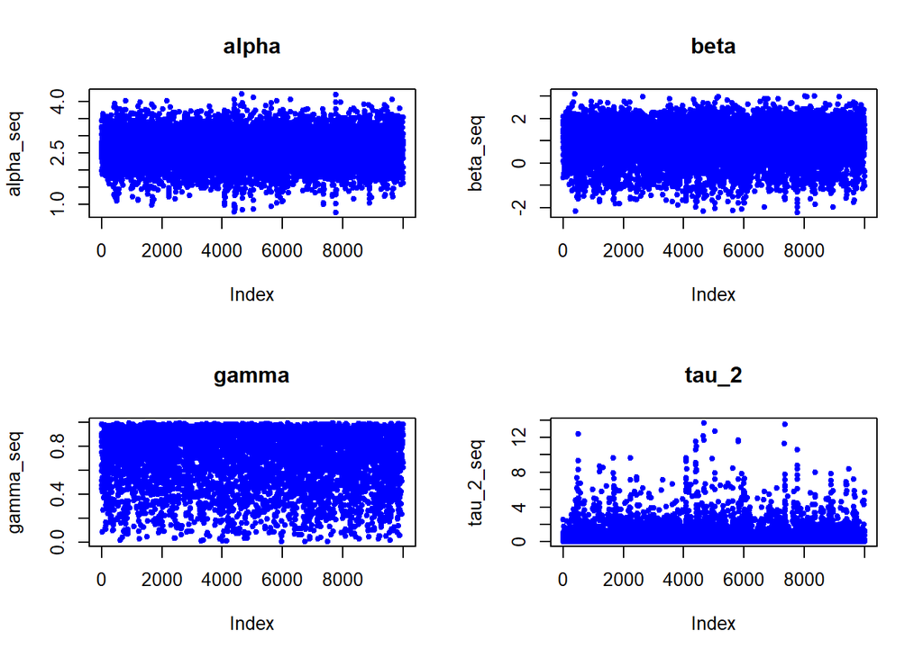

```r
par(mfrow=c(2,2))
plot(alpha_seq, pch = 20, col="blue", cex=1,main = 'alpha')
plot(beta_seq, pch = 20, col="blue", cex=1, main = 'beta')
plot(gamma_seq, pch = 20, col="blue", cex=1, main = 'gamma')
plot(tau_2_seq, pch = 20, col="blue", cex=1, main = 'tau_2')
```

## Point h)

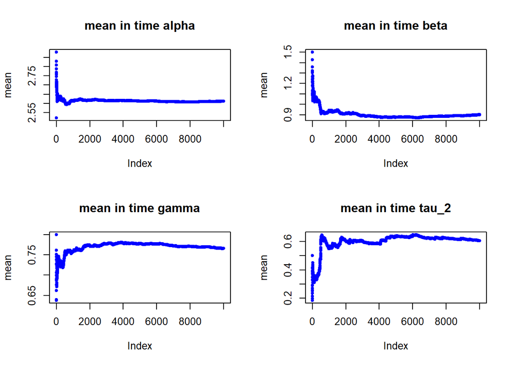

```r
par(mfrow=c(2,2))
plot(cumsum(alpha_seq) / seq_along(alpha_seq), pch = 20, col="blue", cex=1,main = 'mean in time alpha', ylab = 'mean')
plot(cumsum(beta_seq) / seq_along(beta_seq), pch = 20, col="blue", cex=1,main = 'mean in time beta', ylab = 'mean')
plot(cumsum(gamma_seq) / seq_along(gamma_seq), pch = 20, col="blue", cex=1,main = 'mean in time gamma', ylab = 'mean')
plot(cumsum(tau_2_seq) / seq_along(tau_2_seq), pch = 20, col="blue", cex=1,main = 'mean in time tau_2', ylab = 'mean')
```

## Point i)

I’m going to pick the mean, of the values in the Markow chain, as estimator for each parameter.

```r
alpha_optim <- c(mean(alpha_seq), sd(alpha_seq))
alpha_optim
```

```
## [1] 2.6125676 0.4572429
```

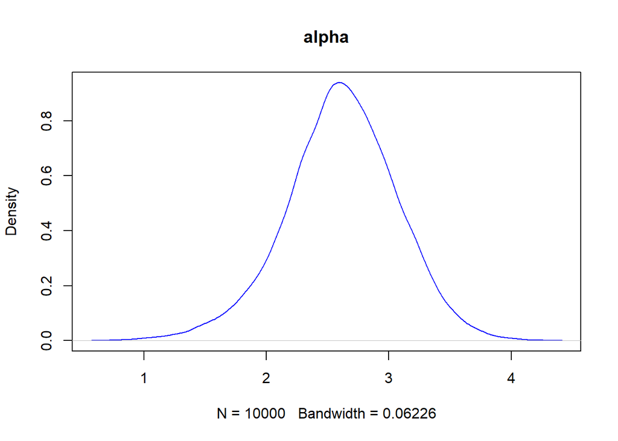

```r
plot(density(alpha_seq), pch = 20, col="blue", cex=1,main = 'alpha')
```

```r
beta_optim <- c(mean(beta_seq), sd(beta_seq))
beta_optim
```

```
## [1] 0.9003468 0.7936364
```

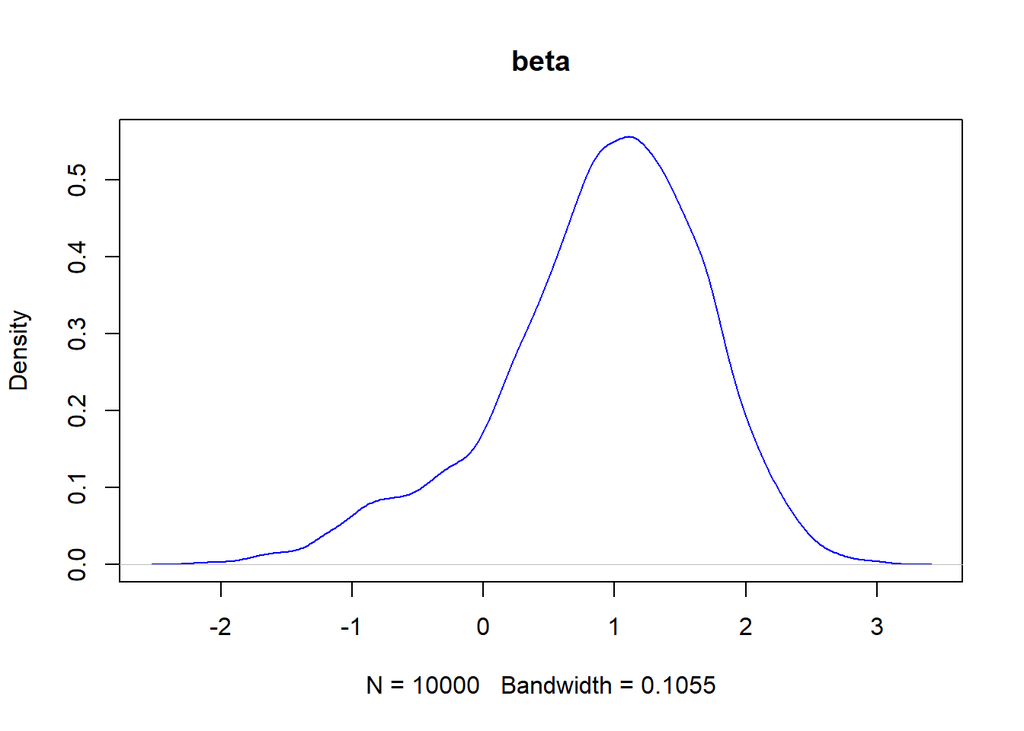

```r
plot(density(beta_seq), pch = 20, col="blue", cex=1,main = 'beta')
```

```r
gamma_optim <- c(mean(gamma_seq), sd(gamma_seq))
gamma_optim
```

```
## [1] 0.7662071 0.2268512
```

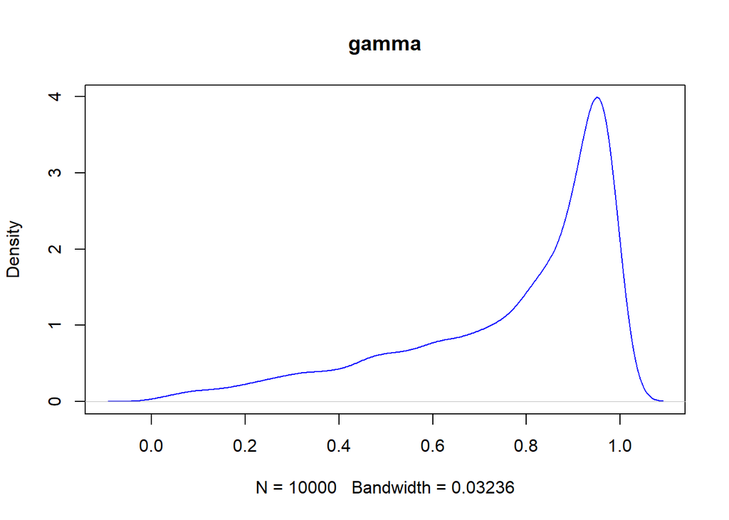

```r
plot(density(gamma_seq), pch = 20, col="blue", cex=1,main = 'gamma')
```

```r
tau_2_optim <- c(mean(tau_2_seq), sd(tau_2_seq))
tau_2_optim
```

```
## [1] 0.6058794 1.1195841
```

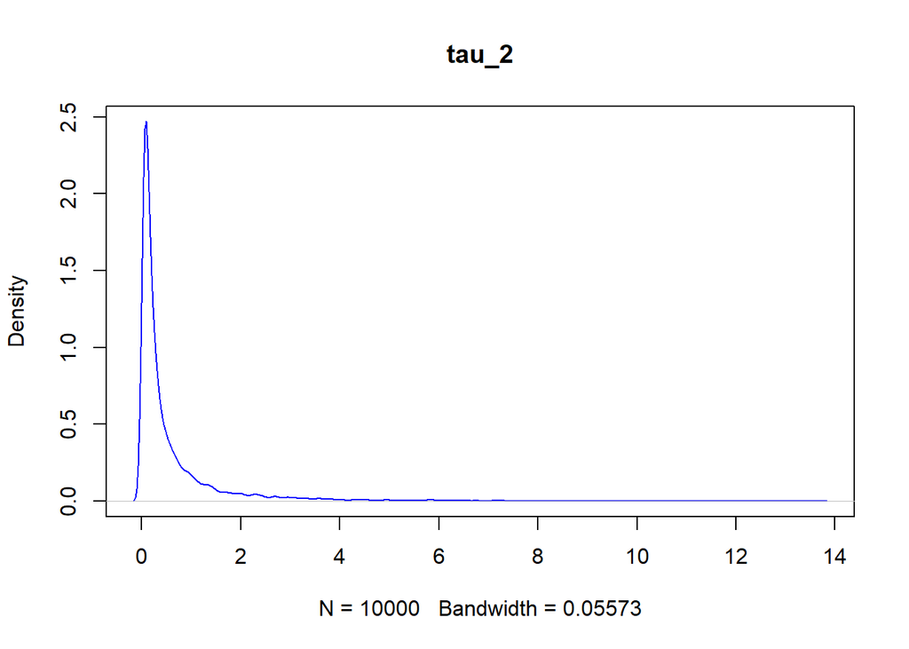

```r
plot(density(tau_2_seq), pch = 20, col="blue", cex=1,main = 'tau_2')
```

## Point j)

I’m going to evaliate the uncertanty as the sd over the mean, in order to rescale it at the same level. Tau_2 have the the largest posterior uncertainty.

```r
alpha_optim[2]/alpha_optim[1]
```

```
## [1] 0.1750167
```

```r
beta_optim[2]/beta_optim[1]
```

```
## [1] 0.8814785
```

```r
gamma_optim[2]/gamma_optim[1]
```

```
## [1] 0.2960703
```

```r
tau_2_optim[2]/tau_2_optim[1]
```

```
## [1] 1.847866
```

## Point k)

Beta and Tau_2 with 0.39. In general beta has a large negative correlation with the other variables.

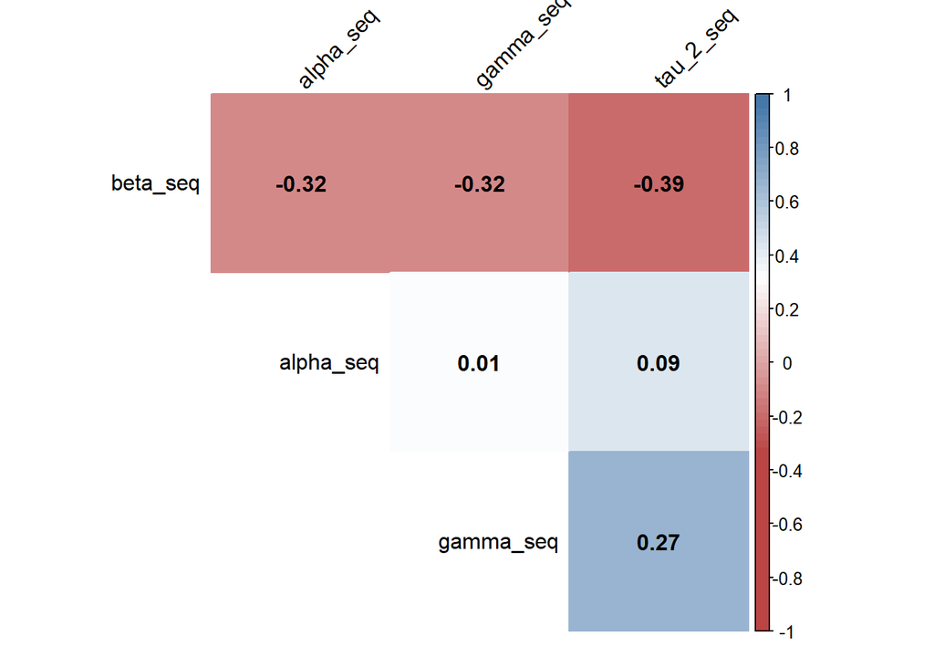

```r
library(corrplot)
par(mfrow=c(1,1))
M <-cor(data.frame(alpha_seq, beta_seq, gamma_seq, tau_2_seq))
col <- colorRampPalette(c("#BB4444", "#BB4444", "#FFFFFF", "#4477AA", "#4477AA"))
corrplot(M, method="color", col=col(100),
         type="upper", order="hclust",
         addCoef.col = "black", # Add coefficient of correlation
         tl.col="black", tl.srt=45, #Text label color and rotation
         # Combine with significance
         #p.mat = p.mat,
         #sig.level = 0.41,
         #insig = "blank",
         # hide correlation coefficient on the principal diagonal
         diag=FALSE
)
```

## Point l)

I’m going to sample the variables as at the point f and after evaluate $Y_i$ with those sampled parameters; it is like integrate over those parameters.

```r
set.seed(187)
n_sim_aux <- 10000

post_predictive_20 <- rep(NA, n_sim_aux)
alpha_seq_20 <- rep(NA, n_sim_aux)
beta_seq_20 <- rep(NA, n_sim_aux)
tau_2_seq_20 <- rep(NA, n_sim_aux)
gamma_seq_20 <- rep(NA, n_sim_aux)

alpha_seq_20[1] <- alpha_optim[1]
beta_seq_20[1] <- beta_optim[1]
tau_2_seq_20[1] <- tau_2_optim[1]
gamma_seq_20[1] <- gamma_optim[1]
post_predictive_20[1] <- rnorm(1, - beta_seq_20[1]*gamma_seq_20[1]^20 + alpha_seq_20[1], 1/sqrt(tau_2_seq_20[1]))

for (i in 2:n_sim_aux){
  # gibbs
  alpha_seq_20[i] <- FC_alpha(beta_seq_20[i-1], gamma_seq_20[i-1], tau_2_seq_20[i-1])
  beta_seq_20[i] <- FC_beta(alpha_seq_20[i], gamma_seq_20[i-1], tau_2_seq_20[i-1])


  # metropolis
  proposed <- FC_gamma(alpha_seq_20[i], beta_seq_20[i], tau_2_seq_20[i-1])

  a <- min(proposed/gamma_seq_20[i-1], 1)
  gamma_seq_20[i] <- sample(c(proposed, gamma_seq_20[i-1]), size = 1, prob = c(a, 1-a))




  # gibbs
  tau_2_seq_20[i] <- FC_tau_2(alpha_seq_20[i], beta_seq_20[i], gamma_seq_20[i])

  # postrerior predictive part
  post_predictive_20[i] <- rnorm(1, - beta_seq_20[i]*gamma_seq_20[i]^20 + alpha_seq_20[i], 1/sqrt(tau_2_seq_20[i]))
}


summary(post_predictive_20)
```

```
##     Min.  1st Qu.   Median     Mean  3rd Qu.     Max.
## -20.2723   0.9555   2.5742   2.5046   4.0794  24.1296
```

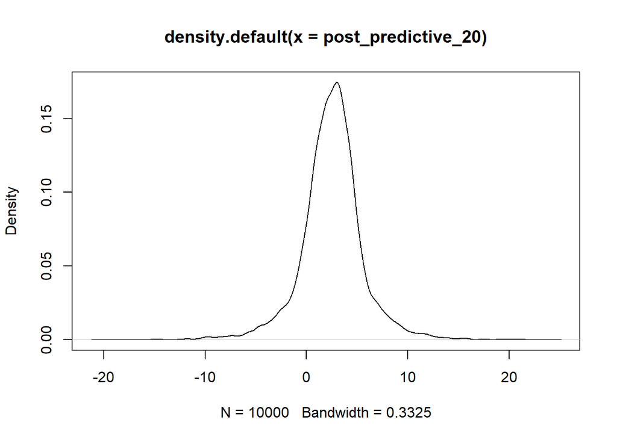

```r
plot(density(post_predictive_20))
```

## Point m)

This is the same of the previous point but with age = 30.

```r
set.seed(134)
n_sim_aux <- 10000

post_predictive_30 <- rep(NA, n_sim_aux)
alpha_seq_30 <- rep(NA, n_sim_aux)
beta_seq_30 <- rep(NA, n_sim_aux)
tau_2_seq_30 <- rep(NA, n_sim_aux)
gamma_seq_30 <- rep(NA, n_sim_aux)

alpha_seq_30[1] <- alpha_optim[1]
beta_seq_30[1] <- beta_optim[1]
tau_2_seq_30[1] <- tau_2_optim[1]
gamma_seq_30[1] <- gamma_optim[1]
post_predictive_30[1] <- rnorm(1, - beta_seq_30[1]*gamma_seq_30[1]^30 + alpha_seq_30[1], 1/sqrt(tau_2_seq_30[1]))

for (i in 2:n_sim_aux){

  # gibbs
  alpha_seq_30[i] <- FC_alpha(beta_seq_30[i-1], gamma_seq_30[i-1], tau_2_seq_30[i-1])
  beta_seq_30[i] <- FC_beta(alpha_seq_30[i], gamma_seq_30[i-1], tau_2_seq_30[i-1])


  # metropolis
  proposed <- FC_gamma(alpha_seq_30[i], beta_seq_30[i], tau_2_seq_30[i-1])

  a <- min(proposed/gamma_seq_30[i-1], 1)
  gamma_seq_30[i] <- sample(c(proposed, gamma_seq_30[i-1]), size = 1, prob = c(a, 1-a))





  # gibbs
  tau_2_seq_30[i] <- FC_tau_2(alpha_seq_30[i], beta_seq_30[i], gamma_seq_30[i])

  # postrerior predictive part
  post_predictive_30[i] <- rnorm(1, - beta_seq_30[i]*gamma_seq_30[i]^30 + alpha_seq_30[i], 1/sqrt(tau_2_seq_30[i]))
}

summary(post_predictive_30)
```

```
##    Min. 1st Qu.  Median    Mean 3rd Qu.    Max.
## -18.593   1.017   2.578   2.530   4.066  21.795
```

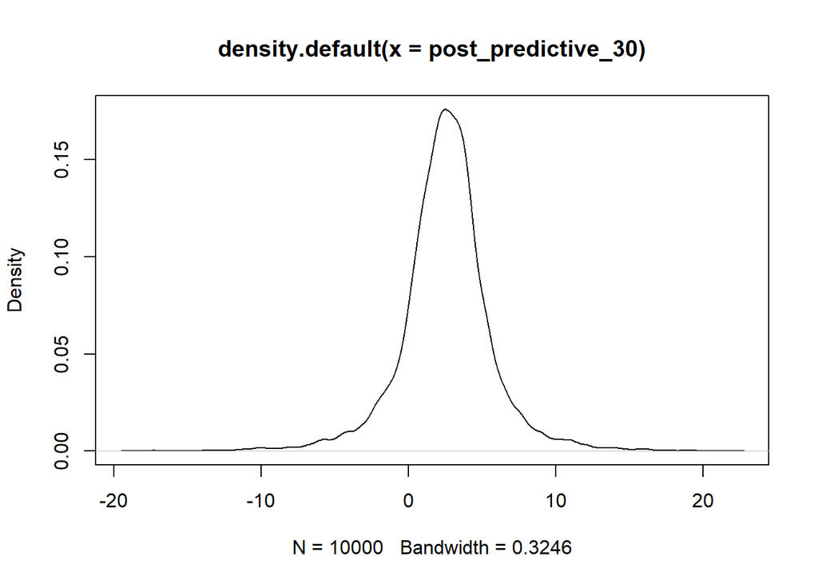

```r
plot(density(post_predictive_30))
```

## Point n)

Both are more or less the same since the spread arround the mean is given by $\frac{1}{\tau}$.

```r
precision_20 <- 1/sd(post_predictive_20)^2
precision_20
```

```
## [1] 0.1008862
```

```r
precision_30 <- 1/sd(post_predictive_30)^2
precision_30
```

```
## [1] 0.1020417
```

## Final considerations)

### Result of beta

The results for $\beta$ are far from what I thought at the beginning … now I can’t believe that a dugong when born has a length of $\alpha - \beta = 2.61 - 0.9 = 1.7 m$ ; obviously the problem is that our points start from $age = 1$ and I think that for smaller ages this model is not good since at the beginning the growth is faster than the prediction of the model.

### Result of tau_2

The problem is that tau_2 allow for solution out of sense, values of thhe posterior predictive distribution are too high or even negative. The problem is that the precision is too low, and I cannot understand why since the datapoints are really close to the mean.

In fact at the beginning I select differents type of prior parameters following this approach:

" since tau_2 is the precision ( $\tau^2 = \frac{1}{\sigma^2}$ ) I want that the mode of this distribution is higher, let’s suppose $6.25$ so I’m going to pick, given the formula $mode = \frac{b}{a+1}$:

$a = 10 \\b = 68.75$"

I have to change this for the optimization porblem, since it has a lot of local minima and due to the results.

### This is not the real story…

Just to be precise the fact that $\alpha$, $\beta$ and $\gamma$ are independent is not true, in fact, the length of a Dugong must be greater than 0, so there are some limitations if we consider one variable given the others. What I made in this hw was just work on the priors considering the problem only at the beginning when $age= 0$, in such a way to consider $\gamma$ as indipendent. For what concern $\alpha$ and $\beta$ I wrote the prior to have a really small intersection so that $\alpha>\beta$ almost always; in this way I consider those two parameters as indipendent.

# Exercise 4)

Defining the values

```r
set.seed(1234)

# support of the chain
S = c(1,2,3)

# initial distribution of the starting point
# (aka marginal of X_0)
mu = c(0.19,0.53,0.28)

# transition probability matrix
P = matrix(c(0.47,0.34,0.04,0.28,0.32,0.53,0.25,0.34,0.43), ncol=3, nrow=3)
```

## Point 0)

this point is not necessary but let’s see if this problem allow a stationary solution and let’s find it

```r
# since there is a lambda = 1 there is a stationary solution (in fact we can evaluate P^n without vanishing)
eigen(t(P))
```

```
## eigen() decomposition
## $values
## [1]  1.00000000  0.27552945 -0.05552945
##
## $vectors
##           [,1]       [,2]       [,3]
## [1,] 0.4653123  0.8163757  0.4998889
## [2,] 0.6553410 -0.4203534 -0.8090360
## [3,] 0.5949895 -0.3960224  0.3091471
```

```r
# let's find the eigenvector with eigenvalue equal to 1 and let's normalize it since it represent a probability distribution (the stationary probability distr)
eigen(t(P))$vector[,1]/sum(eigen(t(P))$vector[,1])
```

```
## [1] 0.2712175 0.3819799 0.3468027
```

```r
# check to see if it is the stationary solution.
t(eigen(t(P))$vector[,1]/sum(eigen(t(P))$vector[,1]))%*% P
```

```
##           [,1]      [,2]      [,3]
## [1,] 0.2712175 0.3819799 0.3468027
```

## Point a)

As I saw befor $\pi(X_0)= \mu^T$

```r
pi_0 <- t(mu)
pi_0
```

```
##      [,1] [,2] [,3]
## [1,] 0.19 0.53 0.28
```

## Point b)

We have to move to the next step, so let’s multiply $\pi(X_0)$ with the transition probability matrix.

```r
pi_1 <- pi_0 %*% P
pi_1
```

```
##        [,1]   [,2]   [,3]
## [1,] 0.2807 0.3712 0.3481
```

## Point c)

The joint matrix distribution is, element by element, $P(X_1=r,X_0=c) = P(X_1=r|X_0=c)*P(X_0=c)$

```r
# so the result is
J <- P*matrix(rep(pi_0,3),3,3)
J
```

```
##        [,1]   [,2]   [,3]
## [1,] 0.0893 0.0532 0.0475
## [2,] 0.1802 0.1696 0.1802
## [3,] 0.0112 0.1484 0.1204
```

```r
# check

# correct since
colSums(J) == pi_1
```

```
##      [,1] [,2] [,3]
## [1,] TRUE TRUE TRUE
```

```r
# correct since
rowSums(J) == pi_0
```

```
##      [,1] [,2] [,3]
## [1,] TRUE TRUE TRUE
```

## Point d)

By definition

```r
# by definition
C_1_0 <- P
C_1_0
```

```
##      [,1] [,2] [,3]
## [1,] 0.47 0.28 0.25
## [2,] 0.34 0.32 0.34
## [3,] 0.04 0.53 0.43
```

```r
# With the Bayes rule we have the same result
J/(matrix(rep(pi_0,3),3,3))
```

```
##      [,1] [,2] [,3]
## [1,] 0.47 0.28 0.25
## [2,] 0.34 0.32 0.34
## [3,] 0.04 0.53 0.43
```

## Point e)

I used the Bayes rule

```r
# I'm going to use the hadamard product
C_0_1 <- J/t(matrix(rep(pi_1,3),3,3))
colSums(C_0_1)
```

```
## [1] 1 1 1
```